# Lab 2: Cats vs Dogs

### Part (e) - 2pt

Why did we only use the test data set at the very end? Why is it important that we use the test data as little as possible?

```python
# We use the test set at the end to evaluate the model unbiasedly
# The result returned this way is unbiased and can actually represent the model's performance
# If we use the test data to train the model. The model will work poorly in real life.
```

### Part (f) - 5pt

How does the your best CNN model compare with an 2-layer ANN model (no convolutional layers) on classifying cat and dog images. You can use a 2-layer ANN architecture similar to what you used in Lab 1. You should explore different hyperparameter settings to determine how well you can do on the validation dataset. Once satisified with the performance, you may test it out on the test data.

Hint: The ANN in lab 1 was applied on greyscale images. The cat and dog images are colour (RGB) and so you will need to flatted and concatinate all three colour layers before feeding them into an ANN.

```
Files already downloaded and verified
Files already downloaded and verified
Epoch 1: Train err: 0.493625, Train loss: 0.6954047083854675 |Validation err: 0.483, Validation loss: 0.6915627121925354
Epoch 2: Train err: 0.480125, Train loss: 0.6916598876317342 |Validation err: 0.4605, Validation loss: 0.6865285634994507
Epoch 3: Train err: 0.450875, Train loss: 0.6862585147221884 |Validation err: 0.431, Validation loss: 0.6810657978057861
Epoch 4: Train err: 0.430625, Train loss: 0.6808498501777649 |Validation err: 0.438, Validation loss: 0.6764125823974609
Epoch 5: Train err: 0.419, Train loss: 0.6767455736796061 |Validation err: 0.4295, Validation loss: 0.6730007529258728
Epoch 6: Train err: 0.412, Train loss: 0.6723826924959818 |Validation err: 0.419, Validation loss: 0.6704907417297363
Epoch 7: Train err: 0.41, Train loss: 0.6697817842165629 |Validation err: 0.4165, Validation loss: 0.6687089800834656
Epoch 8: Train err: 0.405375, Train loss: 0.6676492691040039 |Validation err: 0.418, Validation loss: 0.6674296855926514
Epoch 9: Train err: 0.404375, Train loss: 0.6653250455856323 |Validation err: 0.414, Validation loss: 0.666384220123291
Epoch 10: Train err: 0.403375, Train loss: 0.664389948050181 |Validation err: 0.405, Validation loss: 0.6653879880905151
Epoch 11: Train err: 0.4025, Train loss: 0.6621700326601664 |Validation err: 0.3965, Validation loss: 0.6643219590187073
Epoch 12: Train err: 0.400625, Train loss: 0.66038578748703 |Validation err: 0.3955, Validation loss: 0.6632346510887146
Epoch 13: Train err: 0.399, Train loss: 0.6595564484596252 |Validation err: 0.397, Validation loss: 0.6621537208557129
Epoch 14: Train err: 0.3935, Train loss: 0.6587034265200297 |Validation err: 0.4, Validation loss: 0.6611277461051941
Epoch 15: Train err: 0.39125, Train loss: 0.6577551563580831 |Validation err: 0.4005, Validation loss: 0.6601960062980652
Epoch 16: Train err: 0.389625, Train loss: 0.6560776233673096 |Validation err: 0.399, Validation loss: 0.6593244671821594
Epoch 17: Train err: 0.389125, Train loss: 0.6548104683558146 |Validation err: 0.3985, Validation loss: 0.6585803627967834
Epoch 18: Train err: 0.389125, Train loss: 0.653242846330007 |Validation err: 0.4005, Validation loss: 0.6578771471977234
Epoch 19: Train err: 0.388125, Train loss: 0.6524566213289896 |Validation err: 0.398, Validation loss: 0.6572754383087158
Epoch 20: Train err: 0.38675, Train loss: 0.6520731846491495 |Validation err: 0.3985, Validation loss: 0.656715989112854
Finished Training
Total time elapsed: 49.98 seconds
```

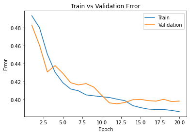

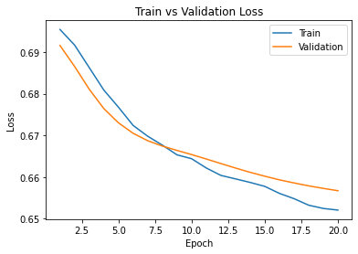

```
Files already downloaded and verified
Files already downloaded and verified
0.379 0.6526457071304321
```

```python
import torch
import torch.nn as nn
import torch.nn.functional as F
from torchvision import datasets, transforms
import matplotlib.pyplot as plt # for plotting
import torch.optim as optim

torch.manual_seed(1) # set the random seed

# define a 2-layer artificial neural network
class Pigeon(nn.Module):
    def __init__(self):
        super(Pigeon, self).__init__()
        self.layer1 = nn.Linear(3*32*32, 30)
        self.layer2 = nn.Linear(30, 1)
        self.name = "ANN"
    def forward(self, img):
        flattened = img.view(-1, 3 *32 * 32)
        activation1 = self.layer1(flattened)
        activation1 = F.relu(activation1)
        activation2 = self.layer2(activation1)
        return activation2.squeeze()

ANN_model = Pigeon()
train_net(ANN_model, 3000, 0.005, 20)
model_path_ANN = get_model_name("ANN", batch_size=3000, learning_rate=0.005, epoch=19)
plot_training_curve(model_path_ANN)

train_loader, val_loader, test_loader, classes = get_data_loader(
    target_classes=["cat", "dog"],
    batch_size = 3000) # 3000 image per batch

criterion = nn.BCEWithLogitsLoss()
test_err, test_loss = evaluate(ANN_model, test_loader, criterion)
print( test_err, test_loss)

#The loss and error is higher in the ANN model
#CNN model works better in this case
```